# BST 260 - Final Project

In-person presidential campaign rallies and trends in country-level COVID-19 cases and deaths

Authors: Daniel Arias, Kritika Anand, and Tianxiao Zhao

**Overview and Motivation**

In-person rallies are large events and may contribute to the spread of COVID-19; in many jurisdictions in the United States, large gatherings have been prohibited or are regulated to promote social distancing and reduce the transmission of COVID-19, and the federal government has issued guidance underscoring the risk large events pose when social distancing may not be readily enforceable. In the lead-up to the November 3 2020 Presidential election, President Trump conducted numerous in-person rallies, both before and after the White House COVID-19 outbreak of September-October 2020. In the 30 days prior to the election, President Trump held 45 in-person rallies across multiple states (Vice President Biden has held numerous drive-in rallies during the same period). Given social distancing guidelines and numerous COVID-19 diagnoses among the President’s re-election campaign (including the President himself), numerous public health researchers, professionals, and observers have raised concerns that the President’s in-person rallies may be contributing to the spread of COVID-19.

Conflicting investigations and working papers have suggested that rallies are and are not associated with local spikes in COVID-19 transmission (Dave et al 2020; Bernheim et al 2020). Motivated by the urgency of the COVID-19 pandemic and the saliency of whether in-person rallies may be associated with excess cases and mortality, we are interested in using time-series data on county-level COVID-19 cases and deaths to visualize trends in transmission in counties in which in-person campaign rallies were hosted and to compare these counties to others in which in-person events were not held. We hope that this analysis will provide additional information on the potential impacts and risks of in-person rallies, encouraging safer measures and accountability for activities that pose risk to the public.

**Related Work**

Two major working papers concerning rallies and COVID-19 transmission are Dave et al. 2020 and Bernheim et al. 2020. The papers reach opposing conclusions, motivating our investigation.

The working paper by Dave and colleagues presents an in-depth inquiry of one presidential campaign rally held by President Trump on June 20, 2020 at the Bank of Oklahoma arena in Tulsa, Oklahoma. The investigators were able to use mobility data to investigate whether non-resident visits to the county increased due to the rally, and whether social distancing behaviors changed among the resident population. The investigators found that while non-resident visitors increased by 25%, social distancing among residents did not attenuate. Using synthetic controls and difference-in-difference, the investigators argue that there was no statistically significant increase in COVID-19 cases associated with the rally.

Bernheim et al., in contrast, explores 18 rallies, matching each to similar counties that did not hold rallies. Counties were matched using 24 different procedures, using regression models that included demographic characteristics, trajectory of cases, and post-event outcomes. The analysis suggests that the average treatment effect associated with hosting a rally likely increased COVID-19 cases by more than 250 per 100,000 people. Extrapolating to the whole sample, Bernheim and colleagues suggest that the 18 rallies resulted in 30,000 additional COVID-19 cases and 700 excess deaths.

Our approach is chiefly inspired from these two papers, further inspired by our courses’ discussion of time-series infectious disease data and choropleth design. Our analysis echoes many of the assignments and in-class demonstrations conducted in the course modules on Data Visualization and Shiny app design.

**Initial Questions**

- Is there a geographic overlap in locations of counties and locations of increased COVID-19 cases, in and around counties that held rallies?
- Did COVID-19 cases increase in counties that held rallies over the subsequent 3 weeks?
- Were counties that held rallies experiencing different levels of COVID-19 cases and deaths (prior to rallies) than comparable counties that did not hold rallies?
- Was the presence of a Trump rally in a county associated with a significant change in the trend of COVID-19 cases and deaths in the ensuing period, compared to similar counties that did not host rallies?

**Data**

Our data were collected from the following sources:

- COVID-19 case and death data at the county-level were collected from the Center for Systems Science and Engineering, Johns Hopkins University: https://github.com/CSSEGISandData/COVID-19
- Exposure data (location and date of rallies) were compiled manually from https://en.wikipedia.org/wiki/List_of_post-election_Donald_Trump_rallies, and were verified against the campaign’s posted schedule (https://www.donaldjtrump.com/events/) and composites of the President’s official schedule (https://factba.se/topic/calendar).
- Median income of counties in 2018 data were obtained from the Economic Research Service of the U.S. Department of Agriculture: https://www.ers.usda.gov/data-products/county-level-data-sets/
- County land area size data (used to calculate population density) were obtained from the U.S. Census Bureau: https://www.census.gov/library/publications/2011/compendia/usa-counties-2011.html

We joined county data sets using Federal Information Processing Standard (FIPS) codes, rather the county names, in order to use a standardized referencing system that would minimize the risk of errors and incomplete joins. Each county in the U.S. is assigned a FIPS code, which encodes both the state the county is in as well as the county itself, based on the integers used in the code. The complete FIPS codes for counties can be found at the U.S Department of Agriculture: https://www.nrcs.usda.gov/wps/portal/nrcs/detail/national/home/?cid=nrcs143_013697.

## Step 1: Prepare COVID-19 Data

*COVID-19 data were filtered to exclude American territories and cruise ships, as well as unassigned cases/deaths and blank entries for FIPS.*

```r
## Step 1a: Import Case Dataset
cases <- read_csv(file = file.path(datapath,"time_series_covid19_confirmed_US.csv")) %>%
  mutate(state_fips = as.numeric(substr(FIPS,1,2))) %>%
  mutate(county_fips = as.numeric(substr(FIPS,3,5))) %>%
  mutate(fips = as.numeric(FIPS)) %>%
  drop_na(fips) %>%
  select(-UID, -iso2, -iso3, -code3, -Country_Region, -FIPS) %>%
  filter(Province_State != "American Samoa",
         Province_State != 'Puerto Rico',
         Province_State != "Guam",
         Province_State != "Northern Mariana Islands",
         Province_State != "Virgin Islands",
         Province_State != 'Diamond Princess',
         Province_State != 'Grand Princess',
         Admin2 != "Unassigned") %>%
  rename(county_name = Admin2,
         state_name = Province_State,
         lat = Lat,
         long = Long_,
         full_name = Combined_Key ) %>%
  pivot_longer(contains("/"), names_to = "date", values_to = "cases") %>%
  mutate(date = as.Date(date, "%m/%d/%y"))
## Step 1b: Import Death Dataset
deaths <- read_csv(file = file.path(datapath,"time_series_covid19_deaths_US.csv")) %>%
  mutate(fips = as.numeric(FIPS)) %>%
  drop_na(fips) %>%
  filter(Province_State != "American Samoa",
         Province_State != 'Puerto Rico',
         Province_State != "Guam",
         Province_State != "Northern Mariana Islands",
         Province_State != "Virgin Islands",
         Province_State != 'Diamond Princess',
         Province_State != 'Grand Princess',
         Admin2 != "Unassigned") %>%
  select(-UID, -iso2, -iso3, -code3, -Country_Region, -FIPS, -Lat, -Long_, -Province_State, -Combined_Key, -Admin2) %>%
  pivot_longer(contains("/"), names_to = "date", values_to = "deaths") %>%
  mutate(date = as.Date(date, "%m/%d/%y"))
## Step 1c: Merge the data together
df <- cases %>%
  left_join(deaths, by = c('fips','date')) %>%
  arrange(fips, date)
rm(cases, deaths)

## Step 1d: Load Median Income
income <- read_csv(file = file.path(datapath,"ers-usda.csv")) %>%
  select(median_inc = Median_Household_Income_2018, fips = fips)
## Step 1e: Merge Median Income Info with Full Dataset
df <- df %>%
  left_join(income, by = c('fips'))

# Step 1f: Data cleaning
df <- df[-c(3:7)] # Cleaning data to drop columns that are not needed
df <- rename(df, "population" = "Population")
rm(income)

# Step 1g: Creating a variable that contains the number of new confirmed cases
df <- df %>%
  arrange(date) %>%
  group_by(fips)  %>%
  mutate(new_cases = cases - lag(cases))

# Step 1h: Creating a rolling 7-day average for the number of new confirmed cases
df <- df %>%
  arrange(date) %>%
  group_by(fips) %>%
  mutate(new_cases_7dayavg = rollmean(new_cases, k = 7, fill = NA))

# Step 1i: Creating a new variable that calculates the seven-day rolling average of new cases per million
df <- df %>%
  mutate(new_cases_7dayavg_per_mil_cap = new_cases_7dayavg / population * 1000000)

# Step 1j: Creating a variable that contains the number of deaths
  df <- df %>% arrange(date) %>%
  group_by(fips)  %>%
  mutate(new_deaths = deaths - lag(deaths))

# Step 1k: Creating a rolling 7-day average for the number of new confirmed deaths
df <- df %>%
  arrange(date) %>%
  group_by(fips) %>%
  mutate(new_deaths_7dayavg = rollmean(new_deaths, k = 7, fill = NA))

# Step 1l: Creating a new variable that calculates the seven-day rolling average of new deaths per million
df <- df %>%
  mutate(new_deaths_7dayavg_per_mil_cap = new_deaths_7dayavg / population * 1000000)

# Step 1m: Merging in land area in square miles and creating density variable
land_area <- read_excel(path = file.path(datapath,"Land area by counties.xlsx"))
land_area$fips <- as.numeric(land_area$STCOU)
land_area$land_area <- land_area$LND110200D

df <- df %>%
  left_join(land_area[,c(4,5)], by="fips")
rm(land_area)
df <- df %>%
  mutate(density = population/land_area)
```

## Step 2: Prepare Rally Data

*Note: FIPS codes were assigned based on the county in which the rally took place or the county containing the largest share of the nearest metropolitan area. For example, rallies held in airports near cities were coded to have taken place in the county containing the city, rather than the airport.*

```r
# Step 2a: Import rally data
rally_data <- read_xlsx("../data/rallies_cc_da.xlsx")
rally_data$date <- as.Date(rally_data$date)

# Step 2b: Filter out rallies that predate February 26, 2020 (first community spread in February 26)
rally_data <- rally_data %>%
  filter(date > ymd(200226)) %>%
  filter(date <= max(df$date)) %>%
  select(date, fips) %>%
  mutate(rally = 1)

# Step 2c: Full join rally and COVID-19 data by FIPS code
df <- df %>%
  full_join(rally_data, by = c("fips", "date")) %>%
  group_by(fips) %>%
  mutate(rally_ind = ifelse(sum(rally, na.rm = T) != 0, 1, 0))


# Step 2d: Create days-to-rally variables for rally 1 and rally 2
temp <- df %>%
  group_by(fips) %>%
  filter(sum(rally, na.rm = T) != 0) %>%
  mutate(day_to_rally_1 = date - date[which(rally == 1)][1]) %>%
  mutate(day_to_rally_2 = date - date[which(rally == 1)][2]) %>%
  select(date, fips, day_to_rally_1, day_to_rally_2)

# Step 2f: Join in mutated data and clean
df <- df %>%
  full_join(temp, by = c("fips", "date"))
df$rally <- NULL
rm(temp)
rm(rally_data)
```

Step 3: Prepare Map Data

*Note that Shannon County (FIPS 46113) was renamed to Oglala Lakota County (FIPS 46102) as of May 1st, 2015. We therefore replace FIPS code 46113 with the new code 46102.*

```r
# Step 3a: Downloading map data
us_map = map_data("county")
fips <- data.frame(county.fips)

# Step 3b: Update the renaming of Shannon County, SD to Ogala Lakota, SD
us_map$subregion[us_map$region == "south dakota" & us_map$subregion == "shannon"] <- "ogala lakota"
fips$fips[fips$fips == 46113] <- 46102
fips$polyname[fips$fips == 46102] <- "south dakota,ogala lakota"

# Step 3c: Merging data
us_map$polyname <- paste(us_map$region, us_map$subregion, sep = ",")
us_map <- full_join(fips, us_map, by = "polyname")
rm(fips)

# Step 3d: Merging map data into dataframe
df <- full_join(df, us_map, by = c("fips"))
rm(us_map)
```

**Exploratory Analysis**

We began by visually analyzing our county-level data using heat maps of the United States, in order to identify patterns, missing data, and other issues in coding. Visually displaying the data using a heat map provided both an elegant way to quickly confirm data completeness as well as provide a general sense of the prevailing trends in population distribution, median income, and COVID-19 cases and deaths.

In the graphs below, we present the snapshot of the epidemic on Election Day 2020. To account for variation in day-to-day reporting, we further generated and conducted visual analysis of the 7-day rolling average of cases and deaths, and related both to the population size to provide for per-capita figures. The population-adjusted rolling averages would be used later in the final analysis.

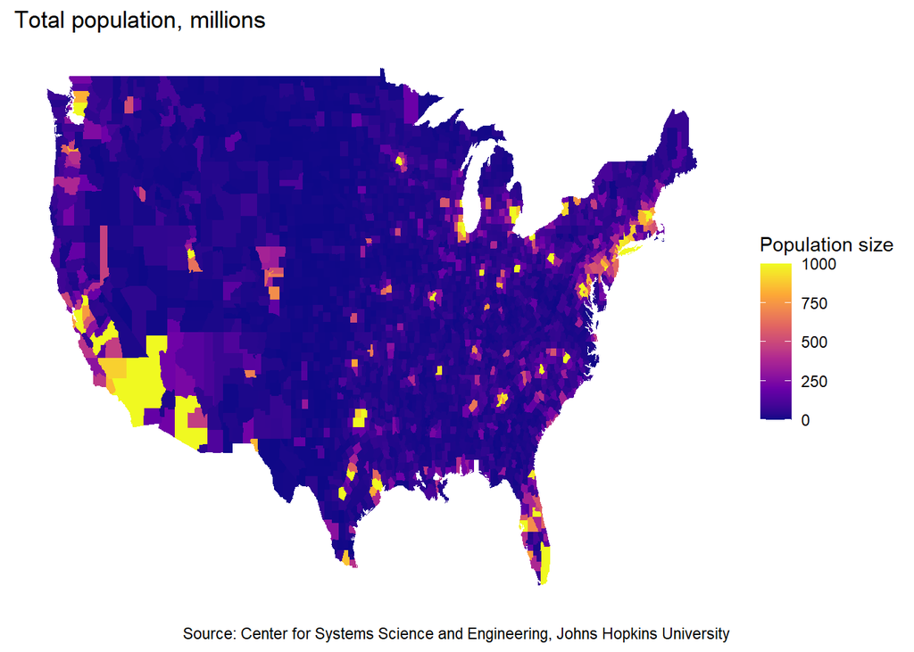

```r
# Step 4a: Map of population
map_0 <- df %>% filter(date == "2020-11-03") %>%
   ggplot(aes(x = long, y = lat, group = group, fill = population/1000)) +
      geom_polygon() +
      theme(panel.grid.major = element_blank(),
            panel.background = element_blank(),
            axis.title = element_blank(),
            axis.text = element_blank(),
            axis.ticks = element_blank()) +
      labs(title="Total population, millions",
        caption="Source: Center for Systems Science and Engineering, Johns Hopkins University",
        fill="Population size") +
   scale_fill_viridis_c(option = "plasma",
                               limits = c(0,1000),    # Forcing upper limit of 1 million pop
                               oob = scales::squish) # Letting values out of bounds be squished to scale

# Step 4b: Map of new confirmed COVID-19 cases per million people
map_1 <- df %>% filter(date == "2020-11-03") %>%
   ggplot(aes(x = long, y = lat, group = group, fill = new_cases_7dayavg_per_mil_cap)) +
      geom_polygon() +
      theme(panel.grid.major = element_blank(),
            panel.background = element_blank(),
            axis.title = element_blank(),
            axis.text = element_blank(),
            axis.ticks = element_blank()) +
      labs(title="Number of new confirmed COVID-19 cases per million people",
        subtitle="on November 3, 2020",
        caption="Source: Center for Systems Science and Engineering, Johns Hopkins University",
        fill="Rolling 7-day average") +
   scale_fill_viridis_c(option = "plasma",
                               limits = c(0,1000),    # Forcing upper limit of 1 thousand cases per million capita per day
                               oob = scales::squish) # Letting values out of bounds be squished to scale

# Step 4c: Map of of new confirmed COVID-19 cases
map_2 <- df %>% filter(date == "2020-11-03") %>%
   ggplot(aes(x = long, y = lat, group = group, fill = new_cases_7dayavg)) +
      geom_polygon() +
      theme(panel.grid.major = element_blank(),
            panel.background = element_blank(),
            axis.title = element_blank(),
            axis.text = element_blank(),
            axis.ticks = element_blank()) +
      labs(title="Number of new confirmed COVID-19 cases",
        subtitle="on November 3, 2020",
        caption="Source: Center for Systems Science and Engineering, Johns Hopkins University",
        fill="Rolling 7-day average") +
   scale_fill_viridis_c(option = "plasma",
                               limits = c(0,150),    # Forcing upper limit of 150 cases per day
                               oob = scales::squish) # Letting values out of bounds be squished to scale

# # Step 4d: Map of cumulative COVID-19 deaths
map_3 <- df %>% filter(date == "2020-11-03") %>%
   ggplot(aes(x = long, y = lat, group = group, fill = deaths)) +
      geom_polygon() +
      theme(panel.grid.major = element_blank(),
            panel.background = element_blank(),
            axis.title = element_blank(),
            axis.text = element_blank(),
            axis.ticks = element_blank()) +
      labs(title="Number of cumulative COVID-19 deaths",
        subtitle="as of November 3, 2020",
        caption="Source: Center for Systems Science and Engineering, Johns Hopkins University",
        fill="Cumulative deaths") +
   scale_fill_viridis_c(option = "plasma",
                               limits = c(0,1000),    # Forcing upper limit of 1000 deaths
                               oob = scales::squish) # Letting values out of bounds be squished to scale

# # Step 4e: Map of new confirmed COVID-19 deaths per million people
map_4 <- df %>% filter(date == "2020-11-03") %>%
   ggplot(aes(x = long, y = lat, group = group, fill = new_deaths_7dayavg_per_mil_cap)) +
      geom_polygon() +
      theme(panel.grid.major = element_blank(),
            panel.background = element_blank(),
            axis.title = element_blank(),
            axis.text = element_blank(),
            axis.ticks = element_blank()) +
      labs(title="Number of new confirmed COVID-19 deaths per million people",
        subtitle="on November 3, 2020",
        caption="Source: Center for Systems Science and Engineering, Johns Hopkins University",
        fill="Rolling 7-day average") +
   scale_fill_viridis_c(option = "plasma",
                               limits = c(0,100),    # Forcing upper limit of 100 deaths per million capita per day
                               oob = scales::squish) # Letting values out of bounds be squished to scale

# Step 4f: Map of new confirmed COVID-19 deaths
map_5 <- df %>% filter(date == "2020-11-03") %>%
   ggplot(aes(x = long, y = lat, group = group, fill = new_deaths_7dayavg)) +
      geom_polygon() +
      theme(panel.grid.major = element_blank(),
            panel.background = element_blank(),
            axis.title = element_blank(),
            axis.text = element_blank(),
            axis.ticks = element_blank()) +
      labs(title="Number of new confirmed COVID-19 deaths",
        subtitle="on November 3, 2020",
        caption="Source: Center for Systems Science and Engineering, Johns Hopkins University",
        fill="Rolling 7-day average") +
   scale_fill_viridis_c(option = "plasma",
                               limits = c(0,10),    # Forcing upper limit of 100 deaths per day
                               oob = scales::squish) # Letting values out of bounds be squished to scale


# Step 4g: Map of median income
map_6 <- df %>% filter(date == "2020-11-03") %>%
   ggplot(aes(x = long, y = lat, group = group, fill = median_inc)) +
      geom_polygon() +
      theme(panel.grid.major = element_blank(),
            panel.background = element_blank(),
            axis.title = element_blank(),
            axis.text = element_blank(),
            axis.ticks = element_blank()) +
      labs(title="Median income",
        caption="Source: USDA",
        fill="Household income, dollars") +
   scale_fill_viridis_c(option = "plasma",
                               limits = c(0,100000),    # Forcing upper limit of 1 million pop
                               oob = scales::squish) # Letting values out of bounds be squished to scale

map_0
```

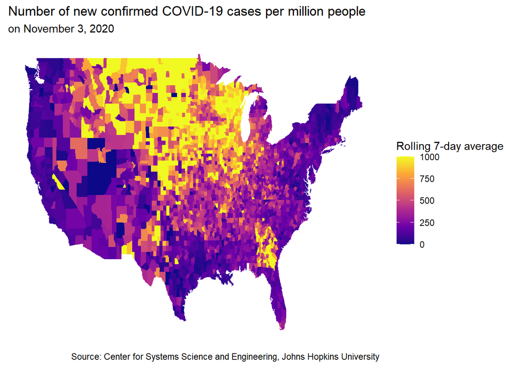

```r
map_1
```

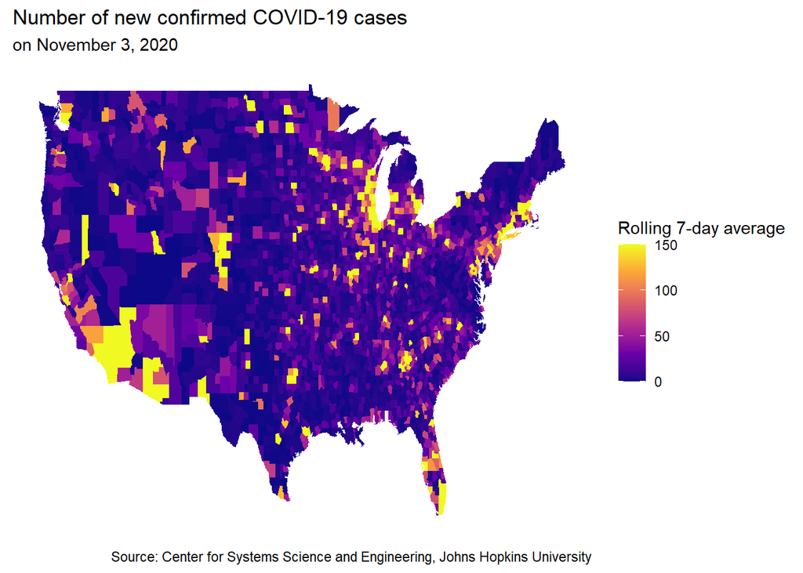

```r
map_2
```

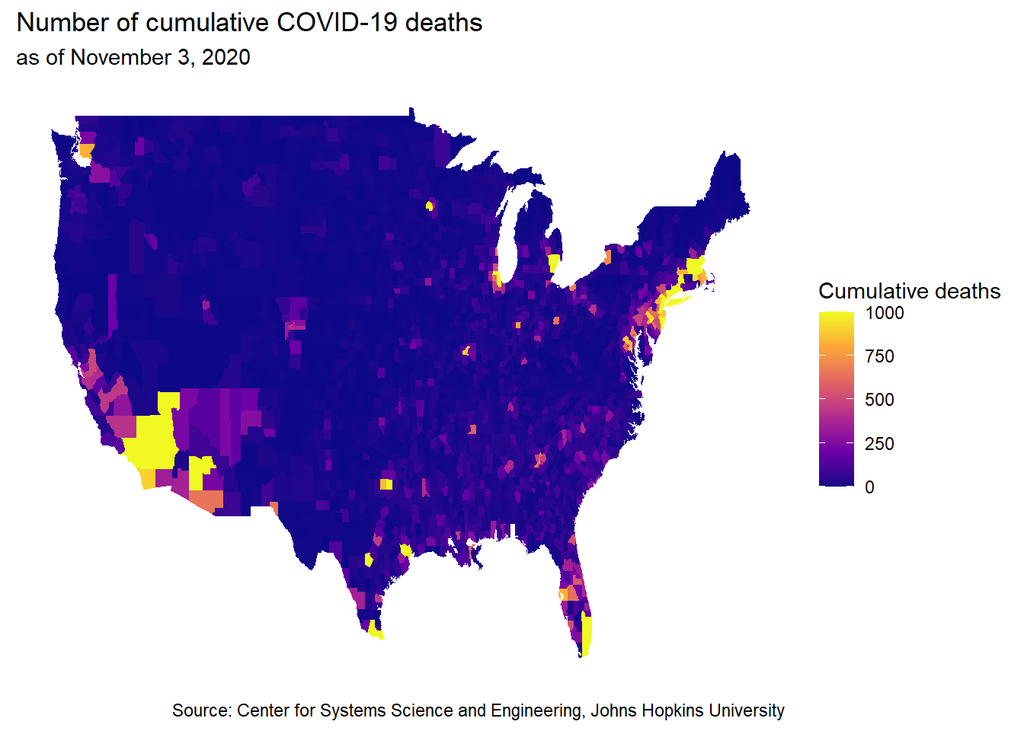

```r
map_3
```

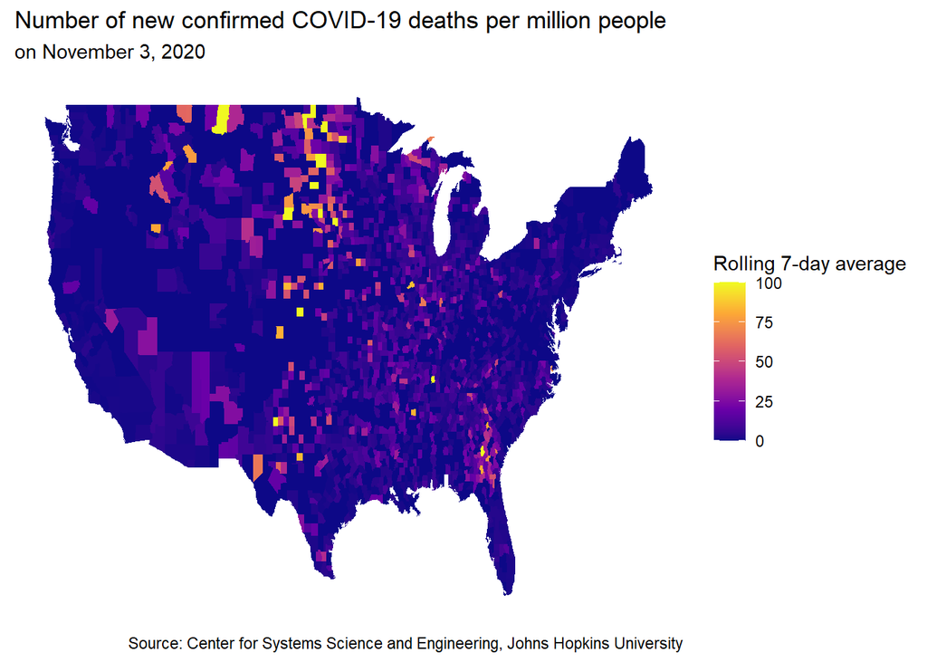

```r
map_4
```

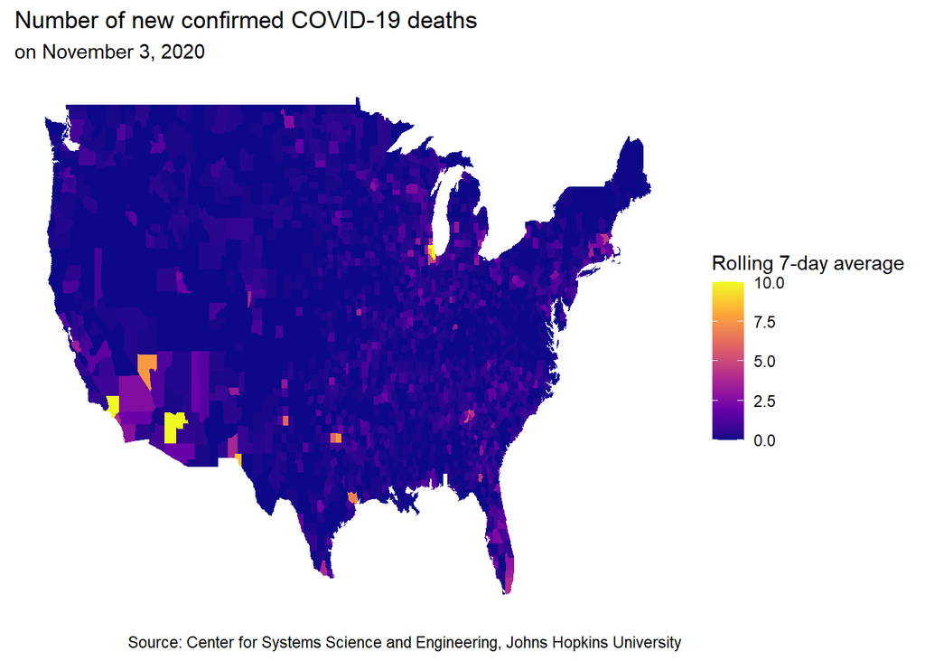

```r
map_5
```

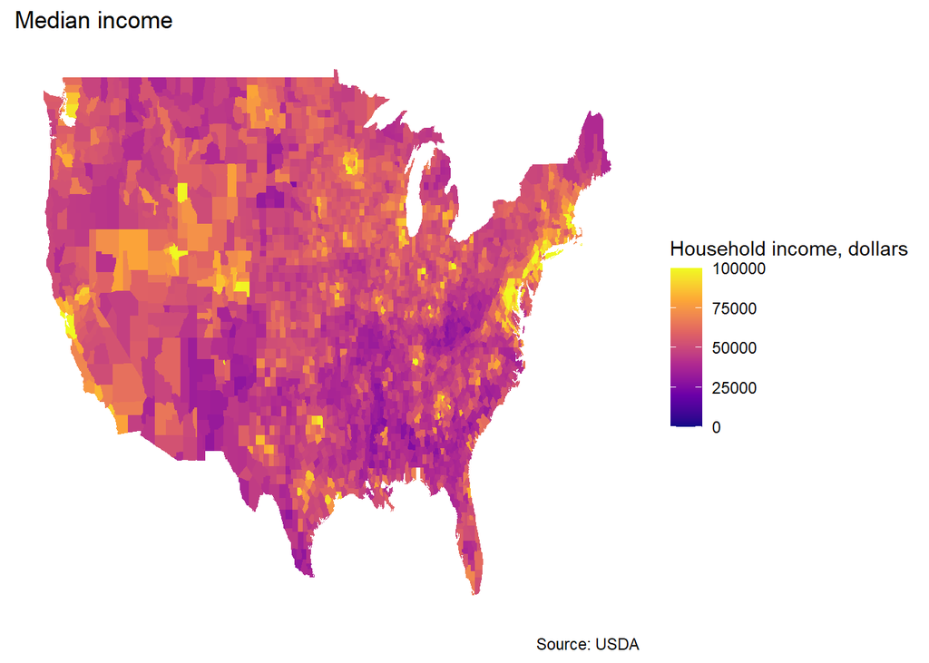

```r
map_6
```

Our maps of population and median income conform with expectations: populations are concentrated in cities, with larger counties (in terms of land area) generally having fewer people (major exceptions include counties in Florida and California, which include non-independent cities). Income appears to be higher in more populous cities, with the lowest levels of income found in Appalachian counties, counties on the southern half of the East Coast, and counties in the Mississippi and Great Plains regions.

In terms of the COVID-19 pandemic, as of Election Day we can see that the number of new cases and deaths were higher in metropolitan regions, due to the population size of these counties. When adjusted into per-capita rates, the burden of the pandemic on Election Day was highest among counties in the West North Central states, as well as several counties in Georgia and New Mexico. This is consistent with epidemiological observations that the pandemic appears to have worsened in North Central states that tended to be affected later than East Coast states in 2020.

Turning to rally data, we began by mapping the locations of rallies. As expected, the rallies tended to be held in locations in battleground states: Arizona, Nevada, Florida, Georgia, the Carolinas, Ohio, Pennsylvania, Michigan, and Wisconsin. The rallies tended to be held in largely populated counties and cities.

Step 5: Map of rally locations, sized by change in cases

```r
# Step 5a: Subset data of rallies
rally <- df %>% filter(rally_ind==1)
df_singledata <- df %>% filter(date == "2020-11-03")
rally <- rally
rally <- rally %>% group_by(fips)  %>%
  summarize_at(vars(long, lat), ~mean(range(.)))
rally <- rally %>% rename("mean_long" = long, "mean_lat" = lat) #To center rally geom_points
rally_covid_data <- df %>% select(1:19)
rally <- inner_join(rally, rally_covid_data, by = c("fips"))
rally <- rally %>% filter(day_to_rally_1 == -14 | day_to_rally_1 == 14)
rally <- rally %>% distinct()
rally <- rally %>% arrange(date) %>%  group_by(fips)  %>%
  mutate(delta_cases = cases - lag(cases))
rally <- rally %>% filter(!is.na(delta_cases))

# Step 5b: Map of rally locations and population of counties
map_7 <- df_singledata %>%
  ggplot() +
  geom_polygon(aes(x = long, y = lat, group = group), fill = "white", color = "grey") +
      theme(panel.grid.major = element_blank(),
            panel.background = element_blank(),
            axis.title = element_blank(),
            axis.text = element_blank(),
            axis.ticks = element_blank()) +
    geom_point(data=rally, aes(x=mean_long, y=mean_lat, size = population/1000000), color="purple4", alpha=0.75) +
        labs(title="Donald Trump presidential campaign rally locations",
        size = "Population, millions",
        caption= "Source: Center for Systems Science and Engineering, Johns Hopkins University.")


# Step 5c: Map of cumulative COVID-19 cases per sq. mile and change in COVID-19 cases before vs. after rallies
map_8 <- df_singledata %>%
  ggplot() +
  geom_polygon(aes(x = long, y = lat, group = group,  fill=cases/land_area), color = "grey") +
      theme(panel.grid.major = element_blank(),
            panel.background = element_blank(),
            axis.title = element_blank(),
            axis.text = element_blank(),
            axis.ticks = element_blank()) +
    geom_point(data=rally, aes(x=mean_long, y=mean_lat, size = delta_cases), color="purple4", alpha=0.75) +
        labs(title="Cumulative COVID-19 cases as of Election Day and rally locations",
        subtitle="Circles indicate change in COVID-19 cases in counties, 2 weeks after vs. before rally",
        size = "Increase in cases in rally counties",
        caption= "Source: Center for Systems Science and Engineering, Johns Hopkins University.",
        fill = " COVID-19 cases per sq. mile") +
    scale_fill_continuous(low = "white", high = "red", na.value = NA,
                          limits = c(0,5),    # Forcing upper limit of 1 thousand cumulative cases per million capita
                               oob = scales::squish) # Letting values out of bounds be squished to scale

summary(rally$delta_cases)
```

```
##    Min. 1st Qu.  Median    Mean 3rd Qu.    Max.
##       1     544    1177    3362    2934   53169
```

```r
rally$county_name[rally$delta_cases == max(rally$delta_cases)]
```

```
## [1] "Maricopa"
```

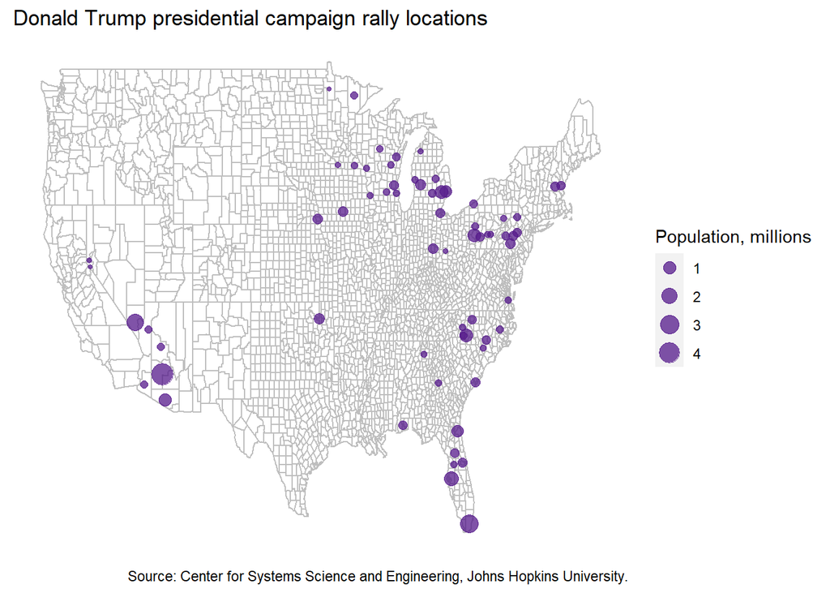

```r
# Step 5d: Tile plot displaying COVID-19 cases per capita, in counties with rallies

graph_tile1 <- df %>%
  filter(rally_ind == 1) %>% # counties with rallies
  filter(day_to_rally_1 %in% -21:21) %>% # 3 weeks before and after
  select(day_to_rally_1, new_cases_7dayavg_per_mil_cap, county_name) %>%
  distinct() %>%
  ggplot(aes(day_to_rally_1, county_name, fill = new_cases_7dayavg_per_mil_cap)) +
  geom_tile(colour = "grey50") +
  scale_x_continuous(expand=c(0,0)) +
  scale_fill_gradientn(colors=brewer.pal(9,"Reds"), trans="sqrt") +
    labs(title="COVID-19 new cases rate by counties with rallies", subtitle = "Square root transformed",
       x="Day(s) to rally", y = "Counties with rallies",
       fill = "Cases per million residents")+
theme(axis.text.y =  element_text(size = "5", hjust = 0))
map_7
```

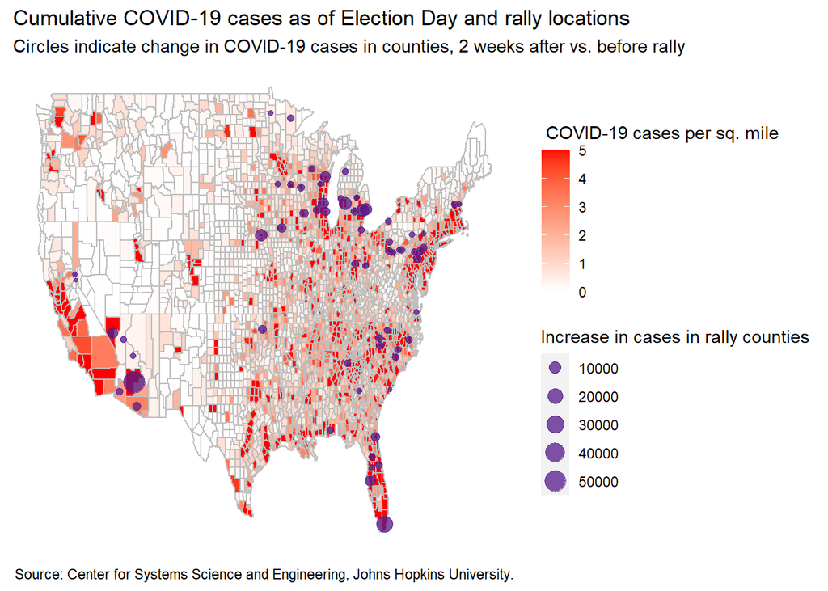

```r
map_8
```

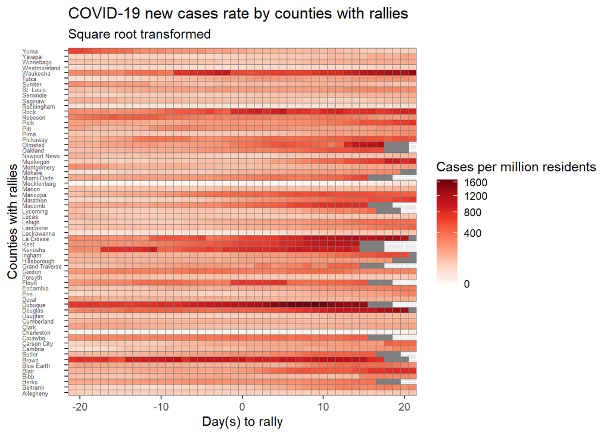

```r
graph_tile1
```

```r
rm(df_singledata)
rm(rally)
```

As a final part of our preliminary analysis, we wanted to understand whether cases increased in counties that held rallies, and whether the location of counties overlapped with higher burdens of cumulative cases over the course of the election year. To do this, we generated a heatmap of cumulative cases per square mile and overlayed the location of rallies on this map. We sized the points identifying the rallies to the number of new cases comparing 2 weeks after rally to 2 weeks prior. All counties saw increases, with the median increase being 1177. The largest increase occurred in Maricopa County, which saw 53,169 new cases over the month-long period.

Using a tile plot, we visualized the rolling 7-day average of new COVID-19 cases per million capita in counties that held rallies. We can see that the counties had varying levels of new cases at baseline, but that most progressed to worsening case rates over time. In most counties, we observe that the case rates were worsening prior to the rally, but the most extreme case rates are observed approximately 7-10 days after rallies occurred, which corresponds to the likely detection period if a spike in transmissions occurred with rally events.

**Final Analysis**

Our final analysis sought to understand the change in cases and deaths in counties with rallies and to compare them to counties that did not hold rallies. In our first step, we constructed population-density weighted lineplots and boxplots to examine the trends and distributions of COVID-19 cases and deaths in counties that held rallies in the 3 weeks before and after a rally.

Step 6: Mean-centered graphs of COVID-19 cases among counties with rallies

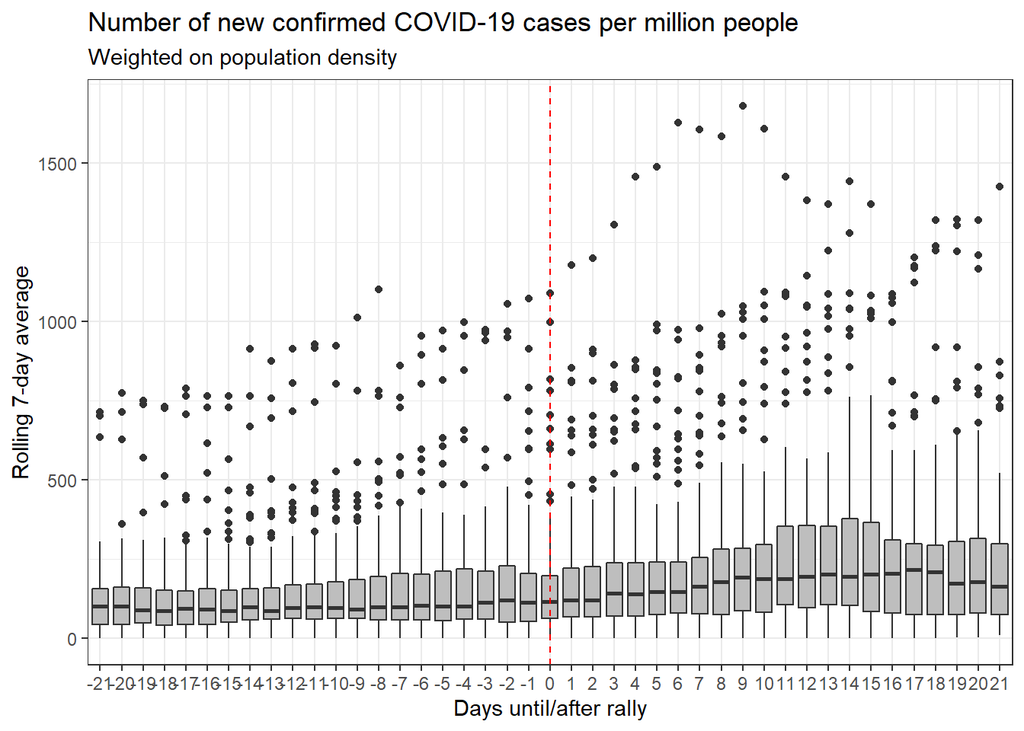

```r
# Step 6a: Boxplot of new cases based weighted on population density

p1 <- df %>%
  filter(rally_ind == 1) %>%
  filter(day_to_rally_1 %in% -21:21) %>%
  group_by(day_to_rally_1) %>%
  mutate(mean_cases = mean(new_cases_7dayavg_per_mil_cap, na.rm = T)) %>%
  ggplot(aes(x = factor(day_to_rally_1),
             y = new_cases_7dayavg_per_mil_cap
             )) +
  geom_boxplot(fill = 'grey') +
  geom_vline(aes(xintercept = factor(0)),
                 colour = "red",
                 linetype = "dashed") +
  labs(title="Number of new confirmed COVID-19 cases per million people",
              subtitle = "Weighted on population density",
    x = "Days until/after rally",
       y = "Rolling 7-day average") +
  theme_bw()

# Step 6b: Lineplot of new cases for the mean weighted on population density

p2 <- df %>%
  filter(rally_ind == 1) %>% # counties with rallies
  filter(day_to_rally_1 %in% -21:21) %>% # 3 weeks before and after
  group_by(day_to_rally_1) %>%
  mutate(mean_cases = weighted.mean(new_cases_7dayavg_per_mil_cap, density, na.rm = T)) %>% # weighted on population density
  select(day_to_rally_1, mean_cases) %>%
  distinct() %>%
  ggplot(aes(x = as.numeric(day_to_rally_1),
             y = mean_cases)) +
  geom_line() +
  geom_vline(aes(xintercept = 0),
                 colour = "red",
                 linetype = "dashed") +
  labs(title="Number of new confirmed COVID-19 cases per million people",
         subtitle = "Mean weighted on population density",
    x = "Days until/after rally",
       y = "Rolling 7-day average") +
  theme_bw()

# Step 6c: Boxplot of new deaths based weighted on population density

p3 <- df %>%
  filter(rally_ind == 1) %>%
  filter(day_to_rally_1 %in% -21:21) %>%
  group_by(day_to_rally_1) %>%
  mutate(mean_cases = mean(new_deaths_7dayavg_per_mil_cap, na.rm = T)) %>%
  ggplot(aes(x = factor(day_to_rally_1),
             y = new_deaths_7dayavg_per_mil_cap
             )) +
  geom_boxplot(fill = 'grey') +
  geom_vline(aes(xintercept = factor(0)),
                 colour = "red",
                 linetype = "dashed") +
  labs(title="Number of new confirmed COVID-19 deaths per million people",
       subtitle = "Weighted on population density",
    x = "Days until/after rally",
       y = "Rolling 7-day average") +
  theme_bw()

# Step 6d: Line plot of new deaths for the mean weighted on population density

p4 <- df %>%
  filter(rally_ind == 1) %>% # counties with rallies
  filter(day_to_rally_1 %in% -21:21) %>% # 3 weeks before and after
  group_by(day_to_rally_1) %>%
  mutate(mean_cases = weighted.mean(new_deaths_7dayavg_per_mil_cap, density, na.rm = T)) %>% # weighted on population density
  select(day_to_rally_1, mean_cases) %>%
  distinct() %>%
  ggplot(aes(x = as.numeric(day_to_rally_1),
             y = mean_cases)) +
  geom_line() +
  geom_vline(aes(xintercept = 0),
                 colour = "red",
                 linetype = "dashed") +
  labs(title="Number of new confirmed COVID-19 deaths per million people",
  subtitle = "Mean weighted on population density",
    x = "Days until/after rally",
       y = "Rolling 7-day average") + ylim(0,4) +
  theme_bw()


p1
```

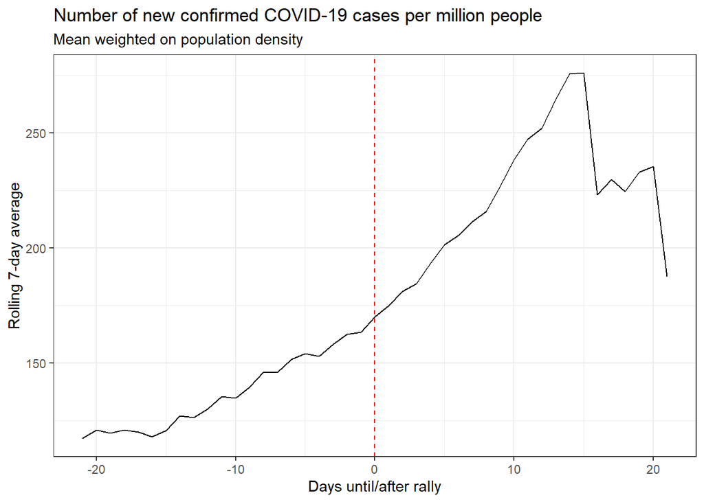

```r
p2
```

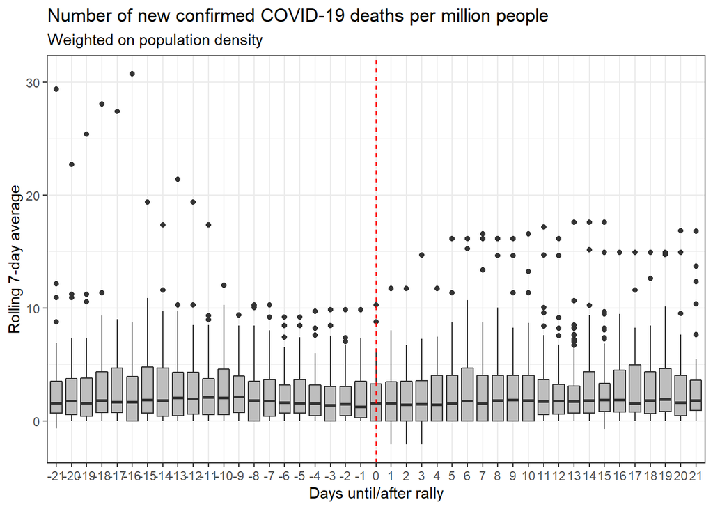

```r
p3
```

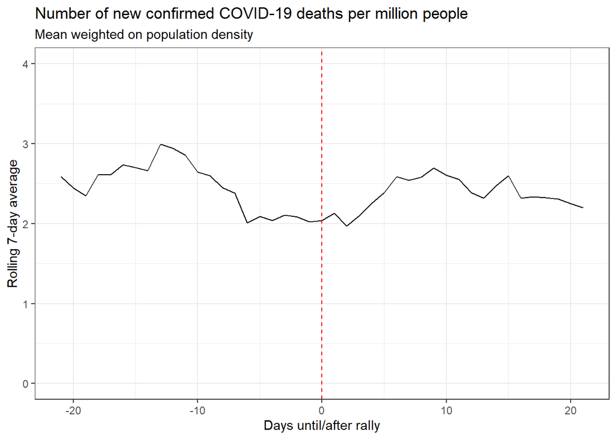

```r
p4
```

To support the primary motivating question, however, we then needed to identify counties without rallies to act as suitable controls for the counties with rallies, in order to determine whether the increases observed were also seen in counties without rallies. If both counties with and without rallies saw a similar upward shift in cases, rallies themselves may not be associated with an increase in cases.

In order to match the control counties to counties that had held a rally, we applied a propensity score matching approach. In the matching model, we considered a county’s population density and its median income to calculate the propensity score (the probability of being a county with a rally). For each rally-county, a nearest neighbor matching method was used to match 5 counties as the control.

Step 7: Propensity score matching

```r
# Step 7a: Propensity score matching based on median income and population density

score <- df %>% select(rally_ind,median_inc,density,fips)
score <- score %>% distinct()
score <- score %>% filter(!is.na(median_inc))
score <- score %>% filter(!is.na(density))
score <- score %>% filter(!is.infinite(density))

fit <- glm(rally_ind ~ median_inc + density, family="binomial" ,data=score)
summary(fit)
```

```
##
## Call:
## glm(formula = rally_ind ~ median_inc + density, family = "binomial",
##     data = score)
##
## Deviance Residuals:
##     Min       1Q   Median       3Q      Max
## -0.6240  -0.2112  -0.1949  -0.1816   2.9187
##
## Coefficients:
##               Estimate Std. Error z value Pr(>|z|)
## (Intercept) -4.944e+00  4.378e-01 -11.294  < 2e-16 ***
## median_inc   1.964e-05  7.359e-06   2.669  0.00761 **
## density      2.459e-05  3.321e-05   0.741  0.45897
## ---
## Signif. codes:  0 '***' 0.001 '**' 0.01 '*' 0.05 '.' 0.1 ' ' 1
##
## (Dispersion parameter for binomial family taken to be 1)
##
##     Null deviance: 632.61  on 3136  degrees of freedom
## Residual deviance: 625.35  on 3134  degrees of freedom
## AIC: 631.35
##
## Number of Fisher Scoring iterations: 6
```

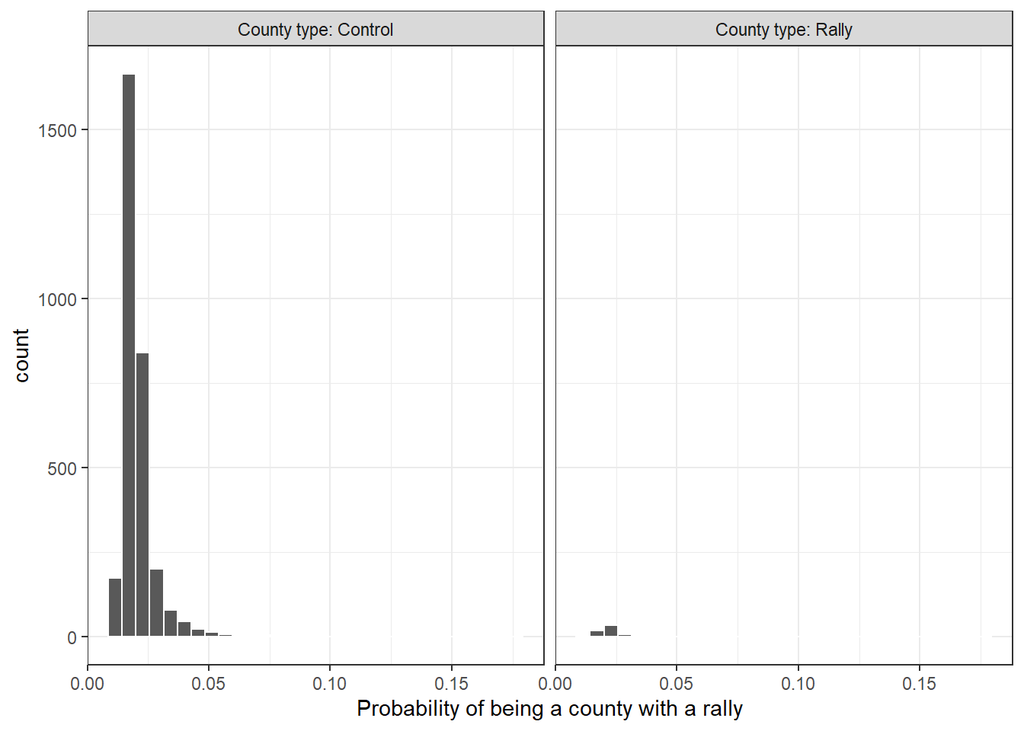

```r
score$pr_score <- predict(fit, type = "response")

labs <- paste("County type:", c("Rally", "Control"))
score %>%
  mutate(rally_ind = ifelse(rally_ind == 1, labs[1], labs[2])) %>%
  ggplot(aes(x = pr_score)) +
  geom_histogram(color = "white") +
  facet_wrap(~rally_ind) +
  xlab("Probability of being a county with a rally") +
  theme_bw()
```

```r
county_match <- matchit(rally_ind ~ median_inc + density , method ="nearest" ,data=score, replace = FALSE, ratio = 5)
dta_m <- match.data(county_match, subclass = "subclass")

summary(county_match)
```

```
##
## Call:
## matchit(formula = rally_ind ~ median_inc + density, data = score,
##     method = "nearest", replace = FALSE, ratio = 5)
##
## Summary of Balance for All Data:
##            Means Treated Means Control Std. Mean Diff. Var. Ratio eCDF Mean
## distance          0.0224        0.0207          0.3329     0.4142    0.1640
## median_inc    57587.6154    52676.4121          0.4591     0.5924    0.1519
## density         598.5315      264.5281          0.5858     0.1006    0.3517
##            eCDF Max
## distance     0.3067
## median_inc   0.2661
## density      0.6311
##
##
## Summary of Balance for Matched Data:
##            Means Treated Means Control Std. Mean Diff. Var. Ratio eCDF Mean
## distance          0.0224        0.0224         -0.0001     1.0126    0.0007
## median_inc    57587.6154    57965.5938         -0.0353     1.0484    0.0118
## density         598.5315      297.4057          0.5281     0.1877    0.3313
##            eCDF Max Std. Pair Dist.
## distance     0.0215          0.0043
## median_inc   0.0677          0.0781
## density      0.5969          1.1693
##
## Percent Balance Improvement:
##            Std. Mean Diff. Var. Ratio eCDF Mean eCDF Max
## distance             100.0       98.6      99.6     93.0
## median_inc            92.3       91.0      92.2     74.6
## density                9.8       27.2       5.8      5.4
##
## Sample Sizes:
##           Control Treated
## All          3072      65
## Matched       325      65
## Unmatched    2747       0
## Discarded       0       0
```

```r
dim(dta_m)
```

```
## [1] 390   8
```

```r
dta_m <- dta_m  %>% select(fips, subclass)
dta_m_1 <- inner_join(dta_m, df, by = c("fips"))


dta_m_2 <- dta_m_1  %>% select(day_to_rally_1, subclass, rally_ind, date)
dta_m_3 <- dta_m_2  %>% filter(rally_ind == 1)
dta_m_3 <- dta_m_3  %>% distinct()
dta_m_3 <- dta_m_3  %>% select(day_to_rally_1, subclass, date)
dta_m_1 <- dta_m_1 %>% select(c(1:18))%>% distinct()

dta_m <- full_join(dta_m_3, dta_m_1, by = c("subclass", "date"))

rm(dta_m_1)
rm(dta_m_2)
rm(dta_m_3)
```

There were 65 counties that had held a Trump rally, and correspondingly, 325 counties were matched as the control. Our visual analysis of the region of common support supported our conclusion that the matching was successful, with meaningful overlap in the propensity scores of both rally and control counties.

The time-series data for the matched controls were centered around the date of the rally held in their matched county. The mean COVID-19 cases and death rates for each day until/after a rally were then calculated in the rally and control group by taking the weighted average of county-level data, weighted by population density.

Step 8: Mean-centered graphs of COVID-19 cases among counties with rallies vs. without

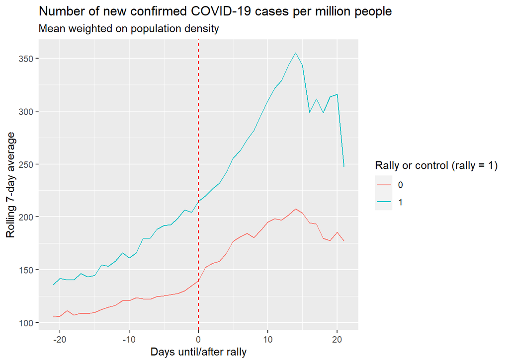

```r
# Step 8a:  Line plot of new cases for the mean weighted on population density in case vs. control counties

p5_data <- dta_m %>%
  filter(day_to_rally_1 %in% -21:21) %>% # 3 weeks before and after
  group_by(rally_ind, day_to_rally_1) %>%
  mutate(mean_cases = weighted.mean(new_cases_7dayavg_per_mil_cap, density, na.rm = T)) %>% # weighted on population density
  select(rally_ind, day_to_rally_1, mean_cases) %>%
  distinct()

p5 <- p5_data %>%
  ggplot(aes(x = as.numeric(day_to_rally_1),
             y = mean_cases,
             color = as.factor(rally_ind))) +
  geom_line() +
  geom_vline(aes(xintercept = 0),
                 colour = "red",
                 linetype = "dashed") +
  labs(title="Number of new confirmed COVID-19 cases per million people",
       subtitle = "Mean weighted on population density",
       color = "Rally or control (rally = 1)",
       x = "Days until/after rally",
       y = "Rolling 7-day average")

p5
```

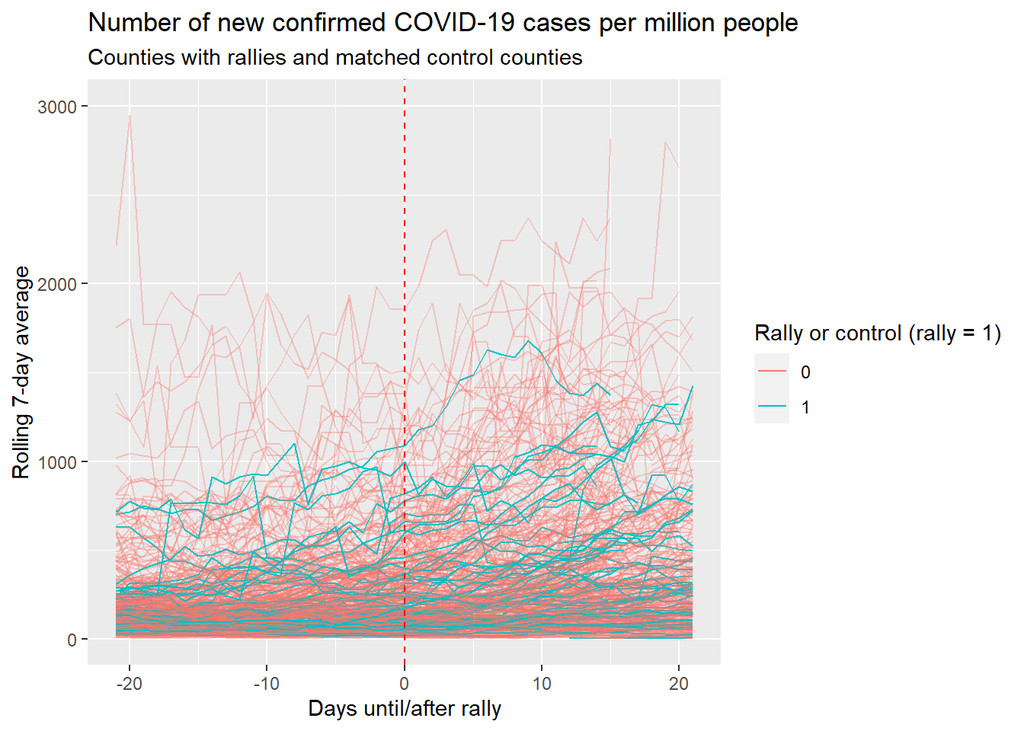

```r
# Step 8b:  Line plot of new cases, case vs. control counties

p6_data <- dta_m %>%
  filter(day_to_rally_1 %in% -21:21) %>% # 3 weeks before and after
  select(fips.y, rally_ind, day_to_rally_1, new_cases_7dayavg_per_mil_cap) %>%
  group_by(fips.y)%>%
  distinct()

p6_data$al <- ifelse(p6_data$rally_ind == 1, 0.95, 0.90)

p6 <- p6_data %>%
  ggplot(aes(x = as.numeric(day_to_rally_1),
             y = new_cases_7dayavg_per_mil_cap,
             group = fips.y,
             alpha = as.factor(rally_ind),
             color = as.factor(rally_ind))) +
    geom_line() +
  geom_vline(aes(xintercept = 0),
                 colour = "red",
                 linetype = "dashed") +
  labs(title="Number of new confirmed COVID-19 cases per million people",
         subtitle = "Counties with rallies and matched control counties",
    x = "Days until/after rally",
    y = "Rolling 7-day average",
    color = "Rally or control (rally = 1)") +
  guides(alpha=F) + ylim(1,3000) +
  scale_alpha_discrete(range = c(0.35, 0.9))
p6
```

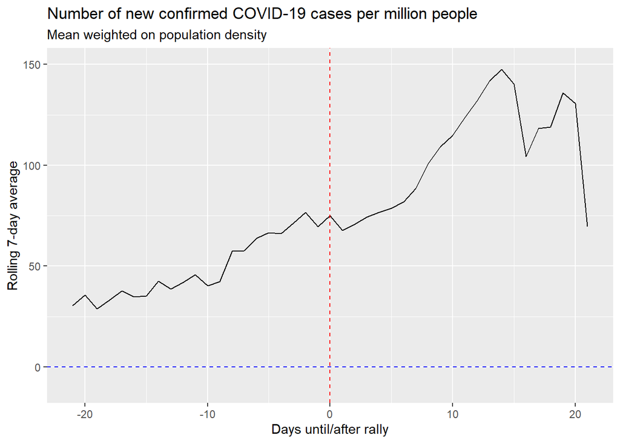

```r
# # Step 8c:  Line plot of difference in cases, case vs. control counties

p7_data <- p5_data %>%
  group_by(day_to_rally_1) %>%
  mutate(diff = mean_cases[which(rally_ind == 1)] - mean_cases[which(rally_ind == 0)]) %>% filter(rally_ind == 1)


p7 <- p7_data %>%
  ggplot(aes(x = as.numeric(day_to_rally_1),
             y = diff
             )) +
  geom_line() +
  geom_vline(aes(xintercept = 0),
                 colour = "red",
                 linetype = "dashed") +
  labs(title="Number of new confirmed COVID-19 cases per million people",
       subtitle = "Mean weighted on population density",
       x = "Days until/after rally",
       y = "Rolling 7-day average") + ylim(-10, 150) +
  geom_hline(aes(yintercept = 0),
             colour = "blue",
             linetype = "dashed")

p7
```

We find this graph to provide evidence to support the conclusion that the presence of a Trump rally in a county was associated with a significant increase in the trend of COVID-19 cases in the ensuing period, compared to similar regions that did not host rallies over the same periods of time. Moreover, rallies were held in counties that had higher per-capita case rates than counties of similar population densities and median income, suggesting the possibility of a common factor associated with both being a county with a worse COVID-19 case rate and being a county where a Trump rally would be hosted.

We note, however, that counties had unique and divergent epidemiological trends, and that visualizing individual counties might provide utility in identifying specific counties that saw spikes and others that appeared to have avoided rally-associated increases in cases. To provide for an interactive analysis, we further constructed a Shiny app, so that individuals could observe county-specific trends in specific counties and compare different measures of the pandemic for visualization.

Our analysis should be understood with a number of limitations. Primarily, we are utilizing county-level data, and have no information on the movement of individuals within or across counties. It is likely that individuals travelling to rallies traveled both within counties and across counties, meaning that transmission could have been affected outside of counties that hosted a rally. Second, our propensity score matching approach is but one way in which matching could have been conducted. While matching based on population density and income was reasonable, additional demographic data, pre-rally COVID-19 trends, and other factors could have been included. Alternatively, we could have utilized a synthetic controls method to construct counterfactual synthetic versions of the rally counties for comparison; in future work, we would intend to utilize this approach and compare it to the propensity score method to understand how the choice of controls affects the conclusion of this investigation.

Our exploratory and final analysis provides evidence to support the conclusion that the presence of a Trump rally in a county associated with a significant change in the trend of COVID-19 cases, though not deaths, in the ensuing period, compared to similar counties that did not host rallies. We find evidence of a geographic overlap in locations of counties and locations of increased COVID-19 cases, in and around counties that held rallies and that counties that held rallies saw higher levels of cases per capita than counties that did not hold rallies, even prior to rallies taking place.